# Ecce Signum: Illustration

# Non-Defense Capitalization

## Loading Packages

This code loads the data into a variable named **ndc**.

```r
## wipe
rm(list=ls())
library(devtools)
```

```
## Error in get(genname, envir = envir) : object 'testthat_print' not found
```

```r
library(Rcpp)

load_all(".")
```

```
## Loading sigex
```

```r
root.dir <- getwd()
```

## Enter Metadata

- We perform a bivariate analysis by fitting a VAR model.
- First enter metadata, including starting date and frequency.

```r
start.date <- c(1992,1)
end.date <- c(2020,5)
period <- 12
```

- Next enter names of the series.
- The last argument of **sigex.load** generates a time series plot.

```r
dataALL.ts <- sigex.load(ndc,start.date,period,
                         c("Shipments","NewOrders"),TRUE)
```

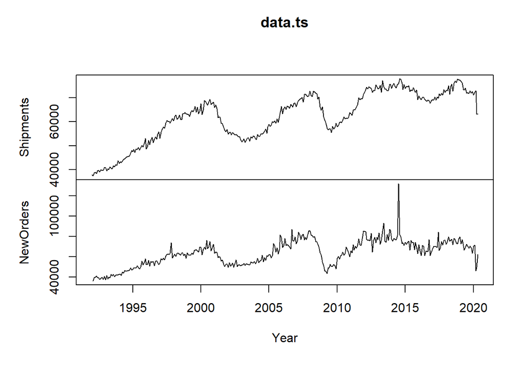

- On the basis of this plot, we decide (below) to utilize no transformation for the data.

## Select Spans and Transforms

- We have the choice of either log or no log.
- The *aggregate* option will sum across the indicated series, in case we want to analyze an aggregate. Here we set it to FALSE.
- We can also select a subcomponent of series with *subseries*.
- The *range* argument of **sigex.prep** will select a subset of dates for the time series to be analyzed.

```r
transform <- "none"
aggregate <- FALSE
subseries <- c(1,2)
begin.date <- start(dataALL.ts)
end.date <- end(dataALL.ts)
range <- NULL
data.ts <- sigex.prep(dataALL.ts,transform,aggregate,subseries,range,TRUE)
```

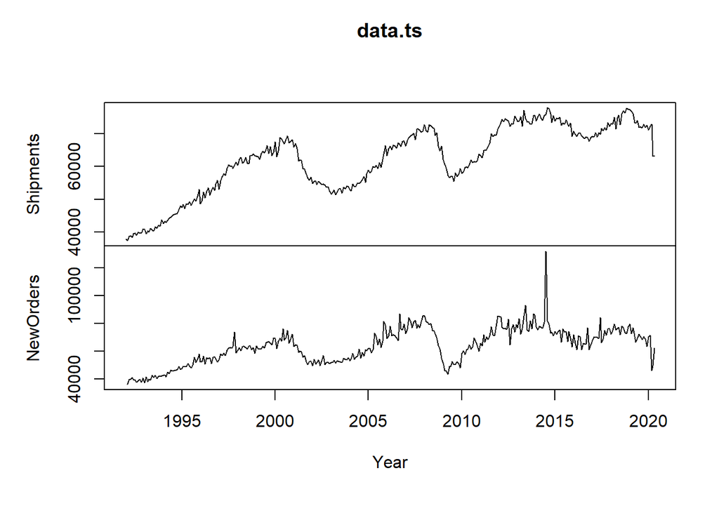

## Model Declaration

- Now we want to define our VAR model.
- We begin by defining dimension $N$ and sample size $T$.

```r
N <- dim(data.ts)[2]
T <- dim(data.ts)[1]
```

### Preliminary Construction

- To define the VAR model, we begin with fitting via Yule-Walker, using base R.
- To do this, we are careful to omit the first observation (due to the missing value), and difference the time series to remove trend non-stationarity.

```r
ar.fit <- ar.yw(diff(ts(ndc[2:T,])))
p.order <- ar.fit$order
```

- The parameter estimates will be used as initial values for our MLE routine.
- But we must first arrange the VAR parameter estimates in the right order, which requires some permuting.
- Also the innovation covariance matrix is broken into its Cholesky decomposition using **getGCD**. This function outputs a list object, including the lower triangular entry of $L$ and the log of the diagonal entries of $D$.

```r
par.yw <- aperm(ar.fit$ar,c(2,3,1))
covmat.yw <- getGCD(ar.fit$var.pred,2)
```

- Next, the array of VAR parameters are mapped via **var.par2pre** to a pre-parameter vector *var.out* of length 28.
- Then *psi.init* is assembled from the Yule-Walker fit, including the sample means, which are incorporated as the last two pre-parameters.

```r
var.out <- var2.par2pre(par.yw)
psi.init <- as.vector(c(covmat.yw[[1]][2,1],log(covmat.yw[[2]]),
                        var.out,colMeans(diff(ts(ndc[2:T,])))))
```

### Model Construction

- Now we define the model.
- The list object *mdl* stores all our specifications about the model, but none of the parameter estimates.

```r
mdl <- NULL
mdl <- sigex.add(mdl,seq(1,N),"varma",c(p.order,0),NULL,"process",c(1,-1))
```

- The call to **sigex.add** indicates there is one main component.
- The second argument indicates the rank configuration for the process; setting *vrank* equal to seq(1,N) ensures a full rank covariance matrix.
- The third argument gives the model type as *varma*;  
  the order $p=7$, $q=0$ of the VARMA is given in the fourth argument.
- The fifth argument provides parameter bounds, and does not apply to this type of model, and hence is set to NULL.
- The sixth argument associates a label.
- The last argument is for the scalar differencing operator $\delta^{(1)} (z)$, expressed as a vector of coefficients.

```r
mdl <- sigex.meaninit(mdl,data.ts,0)
```

- There are no regressors specified, but we still need to call **sigex.meaninit** so that the time trend polynomial is set up correctly.
- The last argument gives the order of this time trend polynomial. The value $0$ indicates there is a constant mean effect assumed.

## Model Estimation

- Now we will fit the model, and check the fit.
- First we need to initialize. The variable *psi.mle* correspond to the pre-parameters, and get mapped to *par.mle*, the parameters, via **sigex.psi2par**.

```r
constraint <- NULL
psi.mle <- psi.init
par.mle <- sigex.psi2par(psi.mle,mdl,data.ts)
```

### MLE Fitting

- Maximum Likelihood Estimation is done using BFGS. We use the divergence, which is $-2$ times the log Gaussian likelihood, with constants removed.
- With the debug option set to TRUE, the values of the divergence are printed to the console.

```r
fit.mle <- sigex.mlefit(data.ts,par.mle,constraint,mdl,"bfgs",debug=FALSE)
psi.mle <- sigex.eta2psi(fit.mle[[1]]$par,constraint)
hess <- fit.mle[[1]]$hessian
par.mle <- fit.mle[[2]]
```

- This yields a divergence of 1.12901710^{4}.
- The MLE pre-parameter is given next.

```r
print(round(psi.mle,digits=4))
```

```
##  [1]  1.5339 14.2420 17.0324 -0.4718  0.4897 -0.0177 -0.3925 -0.3991 -0.0522
## [10]  0.1613 -0.3006  0.1732  0.3665  0.1818 -0.0644  0.1361  0.4965  0.0131
## [19] -0.0819  0.0102  0.4457  0.0898 -0.2688  0.0903  0.0003  0.0485 -0.1443
## [28] -0.0089 -0.0908  0.0516 -0.0326 75.9102 77.8748
```

### Residual Analysis

- We obtain, format, and store the residuals.
- Then we compute the autocorrelations, and plot.

```r
resid.mle <- sigex.resid(psi.mle,mdl,data.ts)[[1]]
resid.mle <- sigex.load(t(resid.mle),start(data.ts),frequency(data.ts),
                        colnames(data.ts),TRUE)
```

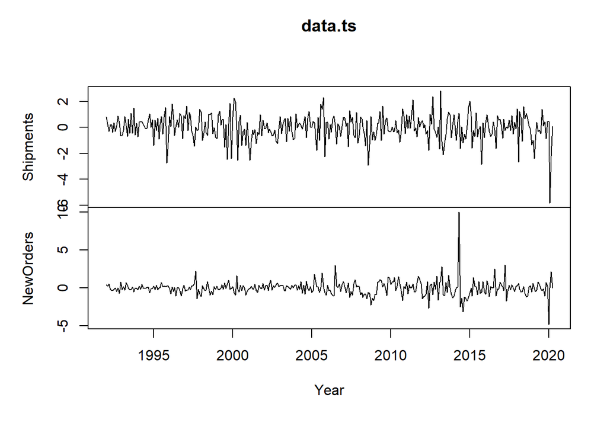

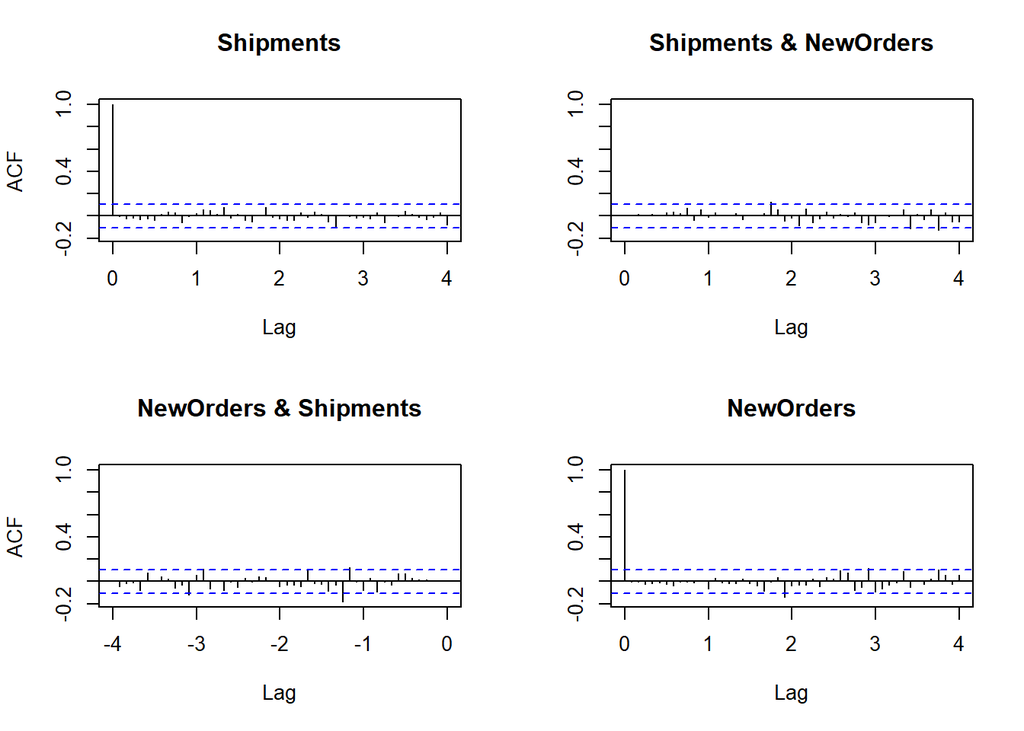

```r
resid.acf <- acf(resid.mle,lag.max=4*period,plot=TRUE)$acf
```

- We can also examine the condition numbers, to see if there is rank reduction possible.
- Typically there won’t be any rank reduction with a single component model.

```r
log(sigex.conditions(data.ts,psi.mle,mdl))
```

```
##      [,1]       [,2]
## eta2    0 -0.1349298
```

### Model Checking

- We can examine the Portmanteau statistic for residual serial correlation. We use $48$ lags.

```r
sigex.portmanteau(resid.mle,4*period,length(psi.mle))
```

```
## [1] 165.1150040   0.3534992
```

- The output indicates there is little residual autocorrelation, which is confirmed by inspection of the sample autocorrelation.
- We can also inspect normality via the Shapiro-Wilks normality test.

```r
sigex.gausscheck(resid.mle)
```

```
## [1] 1.211720e-07 2.548542e-20
```

- There is some non-normality indicated. However, we are not principally interested in the marginal distributions of our time series model.
- We can also examine the Hessian matrix, and compute the t statistics for pre-parameters.

```r
print(eigen(hess)$values)
```

```
##  [1] 1.505231e+04 1.451743e+04 1.370240e+04 1.288381e+04 9.138511e+03
##  [6] 7.935308e+03 5.822688e+03 1.156941e+03 1.025172e+03 8.740588e+02
## [11] 7.451402e+02 6.943003e+02 6.472598e+02 5.850886e+02 5.608084e+02
## [16] 5.067977e+02 4.724578e+02 3.660654e+02 3.600102e+02 3.400193e+02
## [21] 3.392717e+02 3.064807e+02 2.380729e+02 6.190154e+01 4.176580e+01
## [26] 3.391242e+01 3.136005e+01 2.425532e+01 1.938738e+01 1.523997e+01
## [31] 1.287975e+01 1.947712e-03 5.038266e-05
```

- If the Hessian is not positive definite (this can happen if nonlinear optimization terminates wrongfully at a saddlepoint), then the standard error is set to zero.
- In this case there is no problem.

```r
tstats <- sigex.tstats(mdl,psi.mle,hess,constraint)
print(tstats)
```

```
##  [1]   7.008343891 185.555565523 221.895562835  -8.385059033   1.494893523
##  [6]  -0.136216055  -2.122406484  -4.217921294  -0.169513091   2.028259758
## [11]  -1.344123379   2.357346798   1.555516559   3.256473415  -0.381642193
## [16]   2.120320152   2.161263899   0.361059805  -0.536117032   0.196057167
## [21]   1.863424331   2.749472846  -1.799949917   1.914817366   0.001576204
## [26]   1.717321413  -1.122275770  -0.205366025  -0.477556417   2.758243157
## [31]  -0.415454213   0.750303918   0.446004005
```

- These results could be used to insert zeroes in the pre-parameters, although they need not correspond to zeroes in the parameters.

### Bundle

- Having completed our model analysis, we store our results in a single list object.

```r
analysis.mle <- sigex.bundle(data.ts,transform,mdl,psi.mle)
```

## Casting

- Now the modeling and fitting is completed, we can do forecasting and midcasting.
- First we reload from the bundle.
- If we had other fitted models in another bundle, we could load that instead.

```r
data.ts <- analysis.mle[[1]]
mdl <- analysis.mle[[3]]
psi <- analysis.mle[[4]]
param <- sigex.psi2par(psi,mdl,data.ts)
```

- Next, we generate $50$ aftcasts and forecasts.
- Midcast for the missing value at the first time point is automatically generated.
- Uncertainty is also computed.

```r
window <- 50
data.casts <- sigex.midcast(psi,mdl,data.ts,window)
extract.casts <- sigex.castextract(data.ts,data.casts,mdl,window,param)
```

- The output of **sigex.midcast** is a list with two items: the matrix of casts, and a 4-array of casting error covariances.
- Note that these casts are for the series with all fixed effects removed.
- This output can be formatted for use via **sigex.castextract**, which inserts the casts in the correct places in the time series and adds an extended trend regression effect (it is extended forward and backward by the *castspan* value).
- The output of **sigex.castextract** can be utilized by the graphics routine.

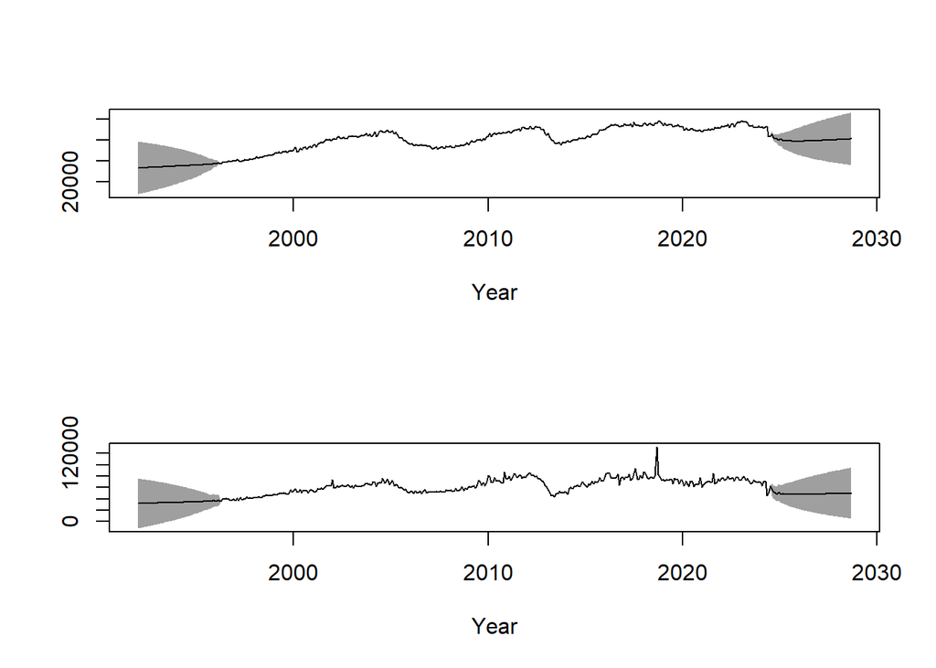

```r
castcol <- "black"
fade <- 60
dataPad.ts <- rbind(matrix(NA,nrow=window,ncol=N),data.ts,matrix(NA,nrow=window,ncol=N))
par(mfrow=c(2,1))
for(i in 1:N)
{
  plot(ts(dataPad.ts[,i],start=start.date,frequency=period),
       xlab="Year",ylab="",lwd=1,col=1,
       ylim=c(min(extract.casts[[3]][,i]),max(extract.casts[[2]][,i])))
  sigex.graph(extract.casts,NULL,start.date,period,i,0,castcol,fade)
}
```

```r
dev.off()
```

- This code sets up grey shading for cast uncertainty.
- For each component time series, the raw data is plotted after first padding with NA before and after.